# Least square with Matrix

Takuma Yamamiya

2018年5月18日

# Least squares formula

複数の説明変数に1つの説明変数を対応させる線形回帰を行う時、

$$Y \sim X\mathbf{a} + b$$
$$\sum_{i=1}^n(y_i-\hat{y_i})^2=\sum_{i=1}^n(y_i-(\mathbf{x_i}^T\mathbf{a}+b))^2
=||Y-(X\mathbf{a}+b)||^2$$
が最小になるような$\mathbf{a}とb$の値を求める。

$b=0$とした時
$$||Y-X\mathbf{a}||^2=(Y-X\mathbf{a})^T(Y-X\mathbf{a})=(Y^T-\mathbf{a}^TX^T)(Y-X\mathbf{a})$$
$\mathbf{a}^TX^TYとY^TX\mathbf{a}$は互いに対称な関係にある式であるが、これはスカラーであるので、同じ値となる。 そこで展開すると
$$Y^TY-2Y^TX\mathbf{a}+\mathbf{a}^TX^TX\mathbf{a}$$
となる。 この式を微分して0となる$\mathbf{a}$を求める。
$$-2Y^TX+(X^TX\mathbf{a})^T+\mathbf{a}^TX^TX=-2Y^TX+2\mathbf{a}^TX^TX=0$$
$$\mathbf{a}^T=Y^TX(X^TX)^{-1}$$
$$\mathbf{a}=(X^TX)^{-1}X^TY$$

b=0の場合について公式が得られたので、b≠0について考える。 以下のようにXに1列足し、
$$X'=\left(\begin{array}{ccc}
\mathbf{x_1}&1\\
\mathbf{x_2}&1\\
.&.\\
.&.\\
.&.\\
\mathbf{x_n}&1
\end{array}
\right)$$

$\mathbf{a}$についても1つ成分を増やし、bにすることで、

$$\mathbf{a'}=
\left(
\begin{array}{ccc}
a_1\\a_2\\.\\.\\.\\a_n\\b
\end{array}
\right
)$$

$$y_i=X'\mathbf{a'}[i,]=\mathbf{x_i}^T\mathbf{a}+b$$
とできるので、b=0の場合と同じように解くことができる。

# 実際にRで計算して比較してみる

まず、$X,\mathbf{a},b$を無作為に設定し、回帰式に乱数を加えたyを作成する。

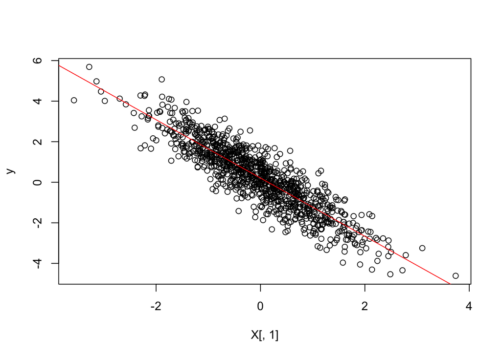

```r
d<-3
n<-1000
X<-matrix(rnorm(d*n),ncol=d)
a<-rnorm(d)
b<-rnorm(1)
y<-X%*%a+b+rnorm(n)*0.1
plot(X[,1],y)
abline(b,a,col=2)
```

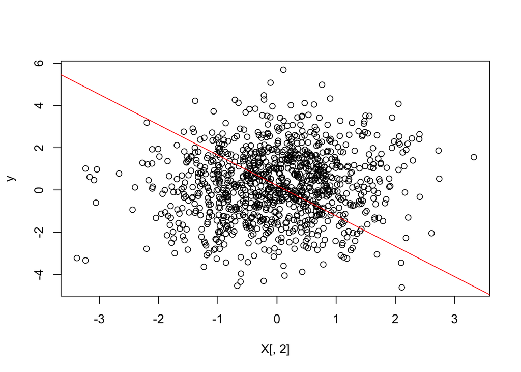

```r
plot(X[,2],y)
abline(b,a,col=2)
```

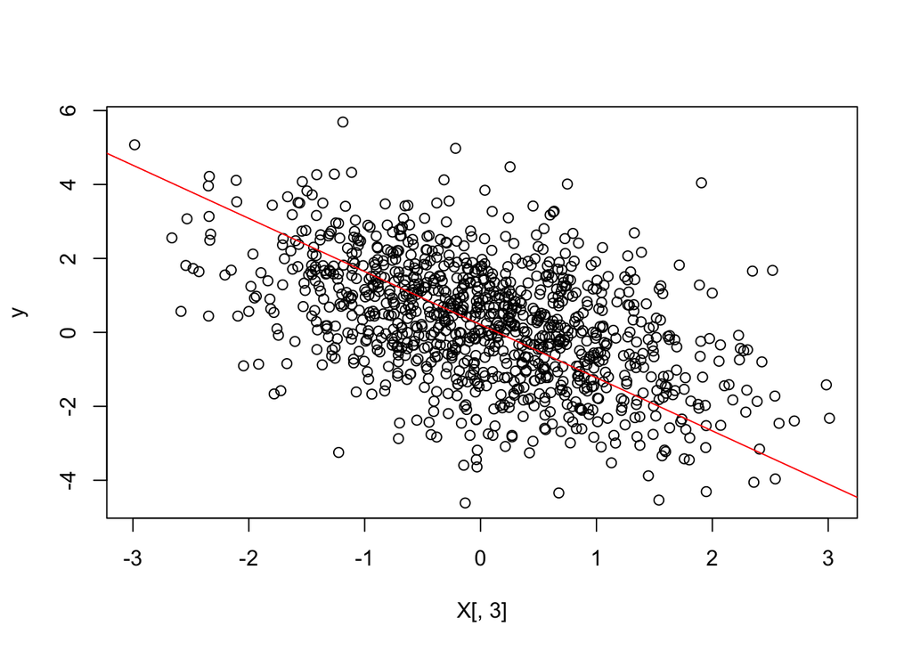

```r
plot(X[,3],y)
abline(b,a,col=2)
```

このX,yについて回帰式を先ほど導いた公式を用いて求める。 b≠0なので、Xを変換し、$\mathbf{a.}$を求める。

```r
X.<-cbind(X,rep(1,n))
a.<-solve(t(X.)%*%X.)%*%t(X.)%*%y
a.
```

```
##            [,1]
## [1,] -1.4339159
## [2,]  0.1825261
## [3,] -0.7013933
## [4,]  0.2097332
```

これで$\mathbf{a}$とbが求められたので、この回帰式によって再びyを計算してみる。

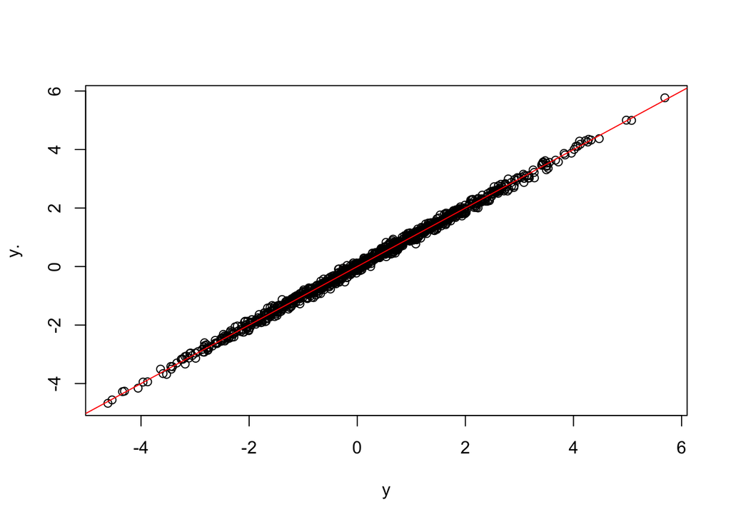

```r
a..<-matrix(c(a.[1,1],a.[2,1],a.[3,1]),3,1)
y.<-X%*%a..+a.[4,1]
plot(y,y.)
abline(0,1,col=2)
```

```r
square<-sum((y-y.)^2)
square
```

```
## [1] 9.646839
```

グラフを見るとうまく回帰出来ているようである。 $\sum_{i=1}^n(y_i-\hat{y_i})^2$が最小値になっているか確認する意味で、求められた$\mathbf{a}$とbの値をいじってみる。

```r
for(i in 1:20){
a..<-matrix(c(a.[1,1]+rnorm(1)*0.01,a.[2,1]+rnorm(1)*0.01,a.[3,1]+rnorm(1)*0.01),3,1)
y.<-X%*%a..+a.[4,1]+rnorm(1)*0.0001
print(sum((y-y.)^2))
}
```

```
## [1] 10.22536
## [1] 9.660795
## [1] 9.736013
## [1] 10.25359
## [1] 9.997624
## [1] 9.724961
## [1] 9.973537
## [1] 9.671777
## [1] 10.12517
## [1] 9.857328
## [1] 9.884129
## [1] 10.17619
## [1] 10.13029
## [1] 10.20626
## [1] 10.06371
## [1] 9.718149
## [1] 9.698204
## [1] 10.005
## [1] 10.43368
## [1] 9.825291
```

いずれも先ほど求めた値より大きいので、どうやら求められた$\mathbf{a}$とbは$\sum_{i=1}^n(y_i-\hat{y_i})^2$が最小値となるものでありそうである。すなわち、もっともらしい回帰式が得られたと考えられる。